# DADA2 - MLSH ITS2 Plate 3 & 4

## Check orientation and read through

```r
primerHits <- function(primer, fn) {
    # Counts number of reads in which the primer is found
    nhits <- vcountPattern(primer, sread(readFastq(fn)), fixed = FALSE)
    return(sum(nhits > 0))
}
rbind(
  FWD.ForwardReads = sapply(FWD.orients, primerHits, fn = fnFs.filtN[[1]]),
  FWD.ReverseReads = sapply(FWD.orients,
    primerHits, fn = fnRs.filtN[[1]]),
  REV.ForwardReads = sapply(REV.orients, primerHits,
    fn = fnFs.filtN[[1]]),
  REV.ReverseReads = sapply(REV.orients, primerHits, fn = fnRs.filtN[[1]]))
```

```
                 Forward Complement Reverse RevComp
FWD.ForwardReads   32295          0       0       0
FWD.ReverseReads       0          0       0   22780
REV.ForwardReads       0          0       0    3040
REV.ReverseReads    7892          0       0       0
```

Checked a few samples. The soil samples seem to have similar number of primer hits in the forward and reverse reads. However, the root samples have much more in the forward than in the reverse. Possibly from primer mismatch on non-target sequences?

Check for the sequencing adapters to see if there are similar counts

```r
rbind(
  FSEQ.ForwardReads = sapply(FSEQ.orients, primerHits, fn = fnFs.filtN[[1]]),
  FSEQ.ReverseReads = sapply(FSEQ.orients,
    primerHits, fn = fnRs.filtN[[1]]),
  RSEQ.ForwardReads = sapply(RSEQ.orients, primerHits,
    fn = fnFs.filtN[[1]]),
  RSEQ.ReverseReads = sapply(RSEQ.orients, primerHits, fn = fnRs.filtN[[1]]))
```

```
                  Forward Complement Reverse RevComp
FSEQ.ForwardReads       0          0       0       0
FSEQ.ReverseReads       0          0       0   36261
RSEQ.ForwardReads       0          0       0   36952
RSEQ.ReverseReads       0          0       0       0
```

Hmm, this suggests that all of the reverse reads have the reverse complement of the forward sequencing primer and all of the forward reads have the reverse complement of the reverse sequencing primer.

# Execute cutadapt from bash script through ssh

The system command was not working properly, so used R to generate adapter and RC sequences and ran bash_cutadapt.sh script.

```r
# cutadapt <- "/home/bryan.emmett/.local/bin/cutadapt"
# system2(command = cutadapt, args = "--version")
```

### Create directory for trimmed sequences

```r
path.cut <- file.path(path, "cutadapt")
if(!dir.exists(path.cut)) dir.create(path.cut)
fnFs.cut <- file.path(path.cut, basename(fnFs))
fnRs.cut <- file.path(path.cut, basename(fnRs))
```

### Define primers

```r
FWD.RC <- dada2:::rc(FWD)
REV.RC <- dada2:::rc(REV)
FWD
REV
FWD.RC
REV.RC

R1.flags <- paste("-g", FWD, "-a", REV.RC)
R2.flags <- paste("-G", REV, "-A", FWD.RC)
R1.flags
R2.flags
```

```r
fnRs.cut[1]
```

## Check cut adapt

```r
rbind(FWD.ForwardReads = sapply(FWD.orients, primerHits, fn = fnFs.cut[[1]]), FWD.ReverseReads = sapply(FWD.orients,
    primerHits, fn = fnRs.cut[[1]]), REV.ForwardReads = sapply(REV.orients, primerHits,
    fn = fnFs.cut[[1]]), REV.ReverseReads = sapply(REV.orients, primerHits, fn = fnRs.cut[[1]]))
```

```
                 Forward Complement Reverse RevComp
FWD.ForwardReads       0          0       0       0
FWD.ReverseReads       0          0       0       0
REV.ForwardReads       0          0       0       0
REV.ReverseReads       0          0       0       0
```

Check for the sequencing adapters to see if there are similar counts

```r
rbind(
  FSEQ.ForwardReads = sapply(FSEQ.orients, primerHits, fn = fnFs.cut[[1]]),
  FSEQ.ReverseReads = sapply(FSEQ.orients,
    primerHits, fn = fnRs.cut[[1]]),
  RSEQ.ForwardReads = sapply(RSEQ.orients, primerHits,
    fn = fnFs.cut[[1]]),
  RSEQ.ReverseReads = sapply(RSEQ.orients, primerHits, fn = fnRs.cut[[1]]))
```

```
                  Forward Complement Reverse RevComp
FSEQ.ForwardReads       0          0       0       0
FSEQ.ReverseReads       0          0       0   19442
RSEQ.ForwardReads       0          0       0   12973
RSEQ.ReverseReads       0          0       0       0
```

A lot of sequences remain with adapter sequences in some root samples. Additionally, many samples with short sequence. After checking, it appears these very short fragments on the forward read are forward primer mismatches so they were not trimmed. The rest of the sequence has been trimmed by the cutadapt, leaving a small fragment. This happens differently based on each sample E.g. fnFs.cut[1] has many, number 2 has relatively few. In the reverse orientation there are also sequencing primer sites early on in the sequence. These are flanked by a long sequences, but likely sequencing junk. Concluding that there are a lot of primer dimers in some samples. Need to re-run cut-adapt and include adapter sequences and filter for fragments smaller than a certain size.  
## Check after second cutadapt round

changing path to cut files to target new cutadapt2 folder

```r
path.cut2 <- file.path(path, "cutadapt2")
#if(!dir.exists(path.cut)) dir.create(path.cut)
fnFs.cut <- file.path(path.cut2, basename(fnFs))
fnRs.cut <- file.path(path.cut2, basename(fnRs))
```

```r
rbind(
  FSEQ.ForwardReads = sapply(FSEQ.orients, primerHits, fn = fnFs.cut[[1]]),
  FSEQ.ReverseReads = sapply(FSEQ.orients,
    primerHits, fn = fnRs.cut[[1]]),
  RSEQ.ForwardReads = sapply(RSEQ.orients, primerHits,
    fn = fnFs.cut[[1]]),
  RSEQ.ReverseReads = sapply(RSEQ.orients, primerHits, fn = fnRs.cut[[1]]))
```

```
                  Forward Complement Reverse RevComp
FSEQ.ForwardReads       0          0       0       0
FSEQ.ReverseReads       0          0       0       0
RSEQ.ForwardReads       0          0       0       0
RSEQ.ReverseReads       0          0       0       0
```

```r
# Forward and reverse fastq filenames have the format:
cutFs <- sort(list.files(path.cut2, pattern = "_R1_001.fastq.gz", full.names = TRUE))
cutRs <- sort(list.files(path.cut2, pattern = "_R2_001.fastq.gz", full.names = TRUE))

# Extract sample names, assuming filenames have format:
get.sample.name <- function(fname) strsplit(basename(fname), "_S")[[1]][1]
sample.names <- unname(sapply(cutFs, get.sample.name))
head(sample.names)
```

```
[1] "KY21_ITS2_1_x_1_R" "KY21_ITS2_1_x_2_R" "KY21_ITS2_1_x_3_R"
[4] "KY21_ITS2_1_x_4_R" "KY21_ITS2_2_x_1_R" "KY21_ITS2_2_x_2_R"
```

```r
sample.names
```

```
  [1] "KY21_ITS2_1_x_1_R"     "KY21_ITS2_1_x_2_R"
  [3] "KY21_ITS2_1_x_3_R"     "KY21_ITS2_1_x_4_R"
  [5] "KY21_ITS2_2_x_1_R"     "KY21_ITS2_2_x_2_R"
  [7] "KY21_ITS2_2_x_3_R"     "KY21_ITS2_2_x_4_R"
  [9] "KY21_ITS2_3_x_1_R"     "KY21_ITS2_3_x_2_R"
 [11] "KY21_ITS2_3_x_3_R"     "KY21_ITS2_3_x_4_R"
 [13] "MLSH_ITS2_193"         "MLSH_ITS2_194"
 [15] "MLSH_ITS2_195"         "MLSH_ITS2_196"
 [17] "MLSH_ITS2_197"         "MLSH_ITS2_198"
 [19] "MLSH_ITS2_199"         "MLSH_ITS2_200"
 [21] "MLSH_ITS2_201"         "MLSH_ITS2_202"
 [23] "MLSH_ITS2_203"         "MLSH_ITS2_204"
 [25] "MLSH_ITS2_205"         "MLSH_ITS2_206"
 [27] "MLSH_ITS2_207"         "MLSH_ITS2_208"
 [29] "MLSH_ITS2_209"         "MLSH_ITS2_210"
```

[output cut: 73 more lines]

# Plot quality profiles and forward and reverse reads

## Forward reads

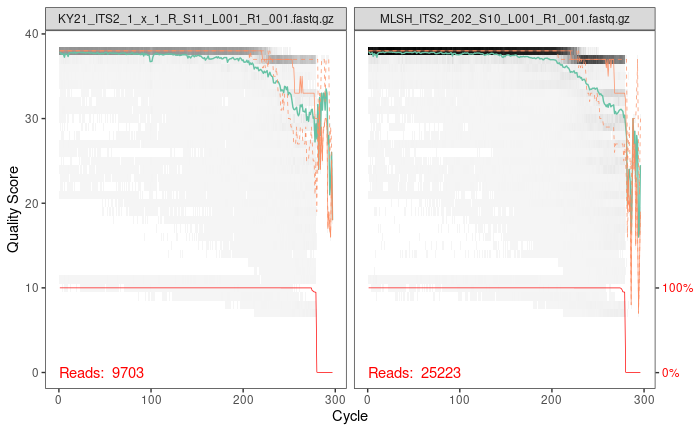

```r
plotQualityProfile(fnFs.cut[c(1,22)])
```

Some files had zero lengths. Re-running the cutadapt script with sequencing adapters and ‘-m 50’ removed these sequences and short sequences. Looks like files may be ready to go.

## Reverse reads

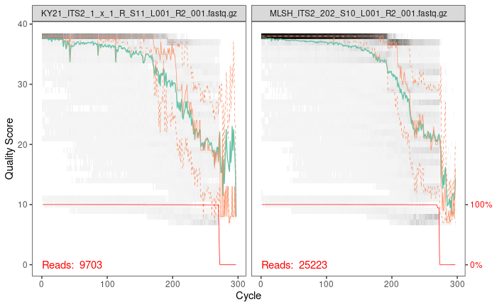

```r
plotQualityProfile(fnRs.cut[c(1,22)])
```

## Last check

```r
readLines(fnFs.cut[1], n = 4)
```

```
[1] "@M01479:477:000000000-L4LHL:1:1102:18485:1931 1:N:0:CCTATGTG+CCTAAACT"
[2] "CGGCTCTTGCATCGATGAAGAACGTAGCGAAATGCGATACTTGGTGTGAATTGCAGAATC…"
[3] "+"
[4] "GGGGGGGGGGGGGGGGGGGGGGGGGGGGGGGGGGGGGGGGGGGGGGGGGGGGGGGGGGGG…<<BF6?ABB>6099BF?BF:FF99?FBFA>A2?DB<0.4>?AF?(9>?F"
```

```r
readLines(fnRs.cut[1], n = 4)
```

```
[1] "@M01479:477:000000000-L4LHL:1:1102:18485:1931 2:N:0:CCTATGTG+CCTAAACT"
[2] "CAGCGGGTAGCCCCGCCTGACCTGAGGTCTCGTTGGGAGCGTGCGTGCACGCAAAGGGTC…"
[3] "+"
[4] "GGGGGGGGGGGGGGGGGGGGGGGGGGGGGGGGGGGGGGGGGG7CGFGGGGGGCGGGGGGGGGGGGGGGGGGGGFGGGGGGGGGGG7FGGGGGGGGGGGGGGGGGGGGGGGGG7CFFGGGGGGGGGFFGCDFGGGGEGGFGGDGEEGGGGGGGDCF9FGGFFGGGGCEGGGGE3<DDGDDGGGGCCDD3)907/8?F9?F@FFE@)(-9919:F?B39ADBA2<)6)4<1<99((2(-,(.3(((..-.)4<A)(-(.((427-(-(-(1("
```

```r
#path
#fastqFs[1]
```

# Filter and trim

```r
filtFs <- file.path(path.cut2, "filtered", basename(cutFs))
filtRs <- file.path(path.cut2, "filtered", basename(cutRs))
```

```r
out <- filterAndTrim(cutFs, filtFs, cutRs, filtRs, maxN = 0, maxEE = c(2, 2), truncQ = 8,
    minLen = 50, rm.phix = TRUE, compress = TRUE, multithread = ncores)  # on windows, set multithread = FALSE
head(out)
```

```
                                           reads.in
KY21_ITS2_1_x_1_R_S11_L001_R1_001.fastq.gz     9703
KY21_ITS2_1_x_2_R_S12_L001_R1_001.fastq.gz    13357
KY21_ITS2_1_x_3_R_S23_L001_R1_001.fastq.gz    26132
KY21_ITS2_1_x_4_R_S24_L001_R1_001.fastq.gz    11182
KY21_ITS2_2_x_1_R_S35_L001_R1_001.fastq.gz    20973
KY21_ITS2_2_x_2_R_S36_L001_R1_001.fastq.gz    15451
                                           reads.out
KY21_ITS2_1_x_1_R_S11_L001_R1_001.fastq.gz      9012
KY21_ITS2_1_x_2_R_S12_L001_R1_001.fastq.gz     12584
KY21_ITS2_1_x_3_R_S23_L001_R1_001.fastq.gz     24602
KY21_ITS2_1_x_4_R_S24_L001_R1_001.fastq.gz     10389
KY21_ITS2_2_x_1_R_S35_L001_R1_001.fastq.gz     19971
KY21_ITS2_2_x_2_R_S36_L001_R1_001.fastq.gz     14710
```

```r
head(out)
```

```
                                           reads.in
KY21_ITS2_1_x_1_R_S11_L001_R1_001.fastq.gz     9703
KY21_ITS2_1_x_2_R_S12_L001_R1_001.fastq.gz    13357
KY21_ITS2_1_x_3_R_S23_L001_R1_001.fastq.gz    26132
KY21_ITS2_1_x_4_R_S24_L001_R1_001.fastq.gz    11182
KY21_ITS2_2_x_1_R_S35_L001_R1_001.fastq.gz    20973
KY21_ITS2_2_x_2_R_S36_L001_R1_001.fastq.gz    15451
                                           reads.out
KY21_ITS2_1_x_1_R_S11_L001_R1_001.fastq.gz      9012
KY21_ITS2_1_x_2_R_S12_L001_R1_001.fastq.gz     12584
KY21_ITS2_1_x_3_R_S23_L001_R1_001.fastq.gz     24602
KY21_ITS2_1_x_4_R_S24_L001_R1_001.fastq.gz     10389
KY21_ITS2_2_x_1_R_S35_L001_R1_001.fastq.gz     19971
KY21_ITS2_2_x_2_R_S36_L001_R1_001.fastq.gz     14710
```

```r
OutFolder = "/project/mmicrobe/MLSH/ITS2"
saveRDS(out, file.path(OutFolder,'FilterTrim.rds'))
```

# Learn errors

```r
set.seed(100)
# Learn forward error rates
errF <- learnErrors(filtFs, multithread = ncores)
```

```
107193644 total bases in 399430 reads from 17 samples will be used for learning the error rates.
```

```r
# Learn reverse error rates
errR <- learnErrors(filtRs, multithread=ncores)
```

```
102673620 total bases in 466779 reads from 21 samples will be used for learning the error rates.
```

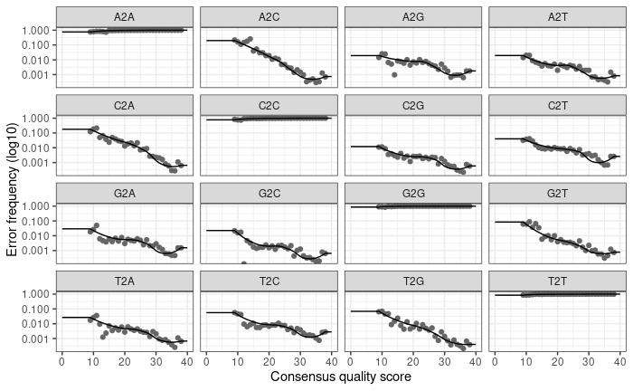

```r
plotErrors(errF)
```

```r
errF_File = file.path(OutFolder,"errF.rds")
saveRDS(errF, errF_File)

errR_File = file.path(OutFolder,"errR.rds")
saveRDS(errR, errR_File)
```

# Sequence Inference

```r
dadaFs <- dada(filtFs, err = errF, multithread = TRUE)
```

```
Sample 1 - 9012 reads in 2647 unique sequences.
Sample 2 - 12584 reads in 2828 unique sequences.
Sample 3 - 24602 reads in 6957 unique sequences.
Sample 4 - 10389 reads in 3417 unique sequences.
Sample 5 - 19971 reads in 5363 unique sequences.
Sample 6 - 14710 reads in 5552 unique sequences.
Sample 7 - 15385 reads in 5474 unique sequences.
Sample 8 - 28156 reads in 8513 unique sequences.
Sample 9 - 39889 reads in 7177 unique sequences.
Sample 10 - 10143 reads in 3825 unique sequences.
Sample 11 - 72412 reads in 13594 unique sequences.
Sample 12 - 14436 reads in 5134 unique sequences.
Sample 13 - 25233 reads in 8850 unique sequences.
Sample 14 - 34619 reads in 13966 unique sequences.
Sample 15 - 17915 reads in 7357 unique sequences.
Sample 16 - 20751 reads in 8270 unique sequences.
Sample 17 - 29223 reads in 10487 unique sequences.
Sample 18 - 20286 reads in 8548 unique sequences.
Sample 19 - 17750 reads in 7516 unique sequences.
Sample 20 - 14121 reads in 6375 unique sequences.
Sample 21 - 15192 reads in 7039 unique sequences.
Sample 22 - 23996 reads in 9252 unique sequences.
Sample 23 - 20424 reads in 8186 unique sequences.
Sample 24 - 20815 reads in 8382 unique sequences.
Sample 25 - 24595 reads in 9330 unique sequences.
Sample 26 - 19991 reads in 8119 unique sequences.
Sample 27 - 16092 reads in 5968 unique sequences.
Sample 28 - 16321 reads in 6958 unique sequences.
Sample 29 - 19589 reads in 7738 unique sequences.
Sample 30 - 16731 reads in 8563 unique sequences.
Sample 31 - 21301 reads in 10038 unique sequences.
Sample 32 - 14734 reads in 6872 unique sequences.
Sample 33 - 24488 reads in 10670 unique sequences.
Sample 34 - 32894 reads in 13442 unique sequences.
Sample 35 - 33933 reads in 12117 unique sequences.
Sample 36 - 20002 reads in 8174 unique sequences.
Sample 37 - 54173 reads in 18757 unique sequences.
Sample 38 - 16906 reads in 7814 unique sequences.
Sample 39 - 20411 reads in 7918 unique sequences.
Sample 40 - 18343 reads in 7928 unique sequences.
```

[output cut: 120 more lines]

```
Sample 161 - 28415 reads in 8590 unique sequences.
Sample 162 - 38800 reads in 13326 unique sequences.
Sample 163 - 38861 reads in 14128 unique sequences.
Sample 164 - 99577 reads in 19682 unique sequences.
Sample 165 - 28879 reads in 11055 unique sequences.
Sample 166 - 34299 reads in 13389 unique sequences.
Sample 167 - 27812 reads in 10302 unique sequences.
Sample 168 - 30616 reads in 10806 unique sequences.
Sample 169 - 23525 reads in 8362 unique sequences.
Sample 170 - 33276 reads in 12556 unique sequences.
Sample 171 - 23369 reads in 8914 unique sequences.
Sample 172 - 76558 reads in 17039 unique sequences.
Sample 173 - 80 reads in 45 unique sequences.
Sample 174 - 1 reads in 1 unique sequences.
Sample 175 - 1 reads in 1 unique sequences.
```

```r
dadaRs <- dada(filtRs, err = errR, multithread = TRUE)
```

```
Sample 1 - 9012 reads in 3915 unique sequences.
Sample 2 - 12584 reads in 4340 unique sequences.
Sample 3 - 24602 reads in 9771 unique sequences.
Sample 4 - 10389 reads in 5179 unique sequences.
Sample 5 - 19971 reads in 7384 unique sequences.
Sample 6 - 14710 reads in 7234 unique sequences.
Sample 7 - 15385 reads in 6951 unique sequences.
Sample 8 - 28156 reads in 10955 unique sequences.
Sample 9 - 39889 reads in 12601 unique sequences.
Sample 10 - 10143 reads in 5261 unique sequences.
Sample 11 - 72412 reads in 22128 unique sequences.
Sample 12 - 14436 reads in 6991 unique sequences.
Sample 13 - 25233 reads in 12494 unique sequences.
Sample 14 - 34619 reads in 18203 unique sequences.
Sample 15 - 17915 reads in 9686 unique sequences.
Sample 16 - 20751 reads in 10738 unique sequences.
Sample 17 - 29223 reads in 13571 unique sequences.
Sample 18 - 20286 reads in 10950 unique sequences.
Sample 19 - 17750 reads in 9654 unique sequences.
Sample 20 - 14121 reads in 8058 unique sequences.
Sample 21 - 15192 reads in 8756 unique sequences.
Sample 22 - 23996 reads in 12351 unique sequences.
Sample 23 - 20424 reads in 10726 unique sequences.
Sample 24 - 20815 reads in 10061 unique sequences.
Sample 25 - 24595 reads in 12291 unique sequences.
Sample 26 - 19991 reads in 10553 unique sequences.
Sample 27 - 16092 reads in 8565 unique sequences.
Sample 28 - 16321 reads in 9261 unique sequences.
Sample 29 - 19589 reads in 10613 unique sequences.
Sample 30 - 16731 reads in 10610 unique sequences.
Sample 31 - 21301 reads in 12684 unique sequences.
Sample 32 - 14734 reads in 9227 unique sequences.
Sample 33 - 24488 reads in 13489 unique sequences.
Sample 34 - 32894 reads in 16538 unique sequences.
Sample 35 - 33933 reads in 14914 unique sequences.
Sample 36 - 20002 reads in 10814 unique sequences.
Sample 37 - 54173 reads in 24627 unique sequences.
Sample 38 - 16906 reads in 10481 unique sequences.
Sample 39 - 20411 reads in 10717 unique sequences.
Sample 40 - 18343 reads in 10394 unique sequences.
```

[output cut: 120 more lines]

```
Sample 161 - 28415 reads in 14304 unique sequences.
Sample 162 - 38800 reads in 18451 unique sequences.
Sample 163 - 38861 reads in 17927 unique sequences.
Sample 164 - 99577 reads in 31801 unique sequences.
Sample 165 - 28879 reads in 15775 unique sequences.
Sample 166 - 34299 reads in 17253 unique sequences.
Sample 167 - 27812 reads in 14451 unique sequences.
Sample 168 - 30616 reads in 14564 unique sequences.
Sample 169 - 23525 reads in 12527 unique sequences.
Sample 170 - 33276 reads in 16835 unique sequences.
Sample 171 - 23369 reads in 12091 unique sequences.
Sample 172 - 76558 reads in 28699 unique sequences.
Sample 173 - 80 reads in 66 unique sequences.
Sample 174 - 1 reads in 1 unique sequences.
Sample 175 - 1 reads in 1 unique sequences.
```

# Merge paired end reads

```r
mergers <- mergePairs(dadaFs, filtFs, dadaRs, filtRs, verbose=TRUE)
```

```
8416 paired-reads (in 40 unique pairings) successfully merged out of 8701 (in 70 pairings) input.
12091 paired-reads (in 50 unique pairings) successfully merged out of 12243 (in 68 pairings) input.
23293 paired-reads (in 72 unique pairings) successfully merged out of 24123 (in 148 pairings) input.
9010 paired-reads (in 58 unique pairings) successfully merged out of 9925 (in 97 pairings) input.
18995 paired-reads (in 64 unique pairings) successfully merged out of 19497 (in 120 pairings) input.
Duplicate sequences in merged output.
12672 paired-reads (in 72 unique pairings) successfully merged out of 14014 (in 144 pairings) input.
13806 paired-reads (in 63 unique pairings) successfully merged out of 14861 (in 137 pairings) input.
Duplicate sequences in merged output.
25964 paired-reads (in 117 unique pairings) successfully merged out of 27598 (in 267 pairings) input.
37651 paired-reads (in 89 unique pairings) successfully merged out of 39385 (in 168 pairings) input.
9033 paired-reads (in 50 unique pairings) successfully merged out of 9827 (in 100 pairings) input.
67418 paired-reads (in 131 unique pairings) successfully merged out of 71474 (in 300 pairings) input.
12760 paired-reads (in 68 unique pairings) successfully merged out of 13964 (in 146 pairings) input.
22737 paired-reads (in 189 unique pairings) successfully merged out of 24385 (in 315 pairings) input.
30132 paired-reads (in 253 unique pairings) successfully merged out of 33309 (in 510 pairings) input.
Duplicate sequences in merged output.
15504 paired-reads (in 151 unique pairings) successfully merged out of 16881 (in 250 pairings) input.
Duplicate sequences in merged output.
17833 paired-reads (in 146 unique pairings) successfully merged out of 19802 (in 315 pairings) input.
Duplicate sequences in merged output.
25238 paired-reads (in 177 unique pairings) successfully merged out of 28073 (in 377 pairings) input.
Duplicate sequences in merged output.
17953 paired-reads (in 150 unique pairings) successfully merged out of 19457 (in 307 pairings) input.
15378 paired-reads (in 139 unique pairings) successfully merged out of 16829 (in 301 pairings) input.
Duplicate sequences in merged output.
12264 paired-reads (in 126 unique pairings) successfully merged out of 13382 (in 244 pairings) input.
13495 paired-reads (in 144 unique pairings) successfully merged out of 14294 (in 267 pairings) input.
Duplicate sequences in merged output.
21256 paired-reads (in 203 unique pairings) successfully merged out of 22790 (in 347 pairings) input.
Duplicate sequences in merged output.
17999 paired-reads (in 139 unique pairings) successfully merged out of 19508 (in 267 pairings) input.
Duplicate sequences in merged output.
18637 paired-reads (in 120 unique pairings) successfully merged out of 19768 (in 249 pairings) input.
21372 paired-reads (in 164 unique pairings) successfully merged out of 23660 (in 323 pairings) input.
17457 paired-reads (in 126 unique pairings) successfully merged out of 19007 (in 281 pairings) input.
Duplicate sequences in merged output.
13865 paired-reads (in 125 unique pairings) successfully merged out of 15271 (in 228 pairings) input.
13840 paired-reads (in 126 unique pairings) successfully merged out of 15339 (in 274 pairings) input.
16515 paired-reads (in 145 unique pairings) successfully merged out of 18447 (in 310 pairings) input.
```

[output cut: 215 more lines]

```
24439 paired-reads (in 213 unique pairings) successfully merged out of 27647 (in 413 pairings) input.
29845 paired-reads (in 194 unique pairings) successfully merged out of 32882 (in 483 pairings) input.
Duplicate sequences in merged output.
23345 paired-reads (in 181 unique pairings) successfully merged out of 26799 (in 346 pairings) input.
Duplicate sequences in merged output.
26501 paired-reads (in 142 unique pairings) successfully merged out of 29606 (in 351 pairings) input.
20439 paired-reads (in 164 unique pairings) successfully merged out of 22674 (in 300 pairings) input.
Duplicate sequences in merged output.
28990 paired-reads (in 180 unique pairings) successfully merged out of 32064 (in 473 pairings) input.
19111 paired-reads (in 147 unique pairings) successfully merged out of 22480 (in 315 pairings) input.
Duplicate sequences in merged output.
70494 paired-reads (in 301 unique pairings) successfully merged out of 75692 (in 489 pairings) input.
59 paired-reads (in 1 unique pairings) successfully merged out of 59 (in 1 pairings) input.
1 paired-reads (in 1 unique pairings) successfully merged out of 1 (in 1 pairings) input.
1 paired-reads (in 1 unique pairings) successfully merged out of 1 (in 1 pairings) input.
```

## Construct sequence table

##3 Checkpoint - read mergers file, construct sequence table and remove chimeras

```r
seqtab <- makeSequenceTable(mergers)
```

[output not shown]

[output cut: 40 more lines]

[output not shown]

```r
dim(seqtab)
```

```
[1]  175 8637
```

## Remove chimeras

```r
seqtab.nochim <- removeBimeraDenovo(seqtab, method="consensus", multithread=ncores, verbose=TRUE)
```

```
Identified 1392 bimeras out of 8637 input sequences.
```

```r
dim(seqtab.nochim)
```

```
[1]  175 7245
```

```r
# Inspect distribution of sequence lengths
table(nchar(getSequences(seqtab.nochim)))
```

```
 50  51  52  53  55  56  57  63  65  67  68  69  73
  1   3   2   3   4   1   2   1   1   1   1   1   1
 74  76  77  78  81  83 107 108 152 153 157 165 189
  1   1   1   1   1   1   1   1   1   1   1   1   1
198 200 202 209 212 213 216 226 228 234 235 237 238
  1   1   1   2   1   1   1   1   1   2   1   1   2
244 247 248 250 255 256 258 259 260 264 265 266 267
  4   1   2   1   2   1   3   2   1   3   3   3   2
268 269 270 271 272 273 274 275 277 278 279 280 281
  1   1   4   1   7  12   4   3   3   2   3   1   2
282 283 284 285 286 288 289 290 291 292 293 294 295
  2   1   7  11   9   5   6   2   4   4  11   4   4
296 297 298 299 300 301 302 303 304 305 306 307 308
  2   5   9   9   9   6  13   9   7   8  14  24  15
309 310 311 312 313 314 315 316 317 318 319 320 321
```

[output cut: 33 more lines]

```r
outFile = file.path(OutFolder,"seqtab-nochim.rds")

saveRDS(seqtab.nochim, outFile)
```

## Checkpoint read seqtab.nochim

```r
CheckPoint = file.path(OutFolder,"seqtab-nochim.rds")

seqtab.nochim = readRDS(CheckPoint)
```

```r
paste("Fraction of reads not attributed to chimeras:", sum(seqtab.nochim)/sum(seqtab))
```

```
[1] "Fraction of reads not attributed to chimeras: 0.958758534345071"
```

# Track reads through pipeline

```r
getN <- function(x) sum(getUniques(x))
track <- cbind(out, sapply(dadaFs, getN), sapply(dadaRs, getN), sapply(mergers, getN),
    rowSums(seqtab.nochim))
```

[output not shown]

[output cut: 40 more lines]

[output not shown]

```r
# If processing a single sample, remove the sapply calls: e.g. replace
# sapply(dadaFs, getN) with getN(dadaFs)
colnames(track) <- c("input", "filtered", "denoisedF", "denoisedR", "merged", "nonchim")
rownames(track) <- sample.names
head(track)
```

```
                  input filtered denoisedF denoisedR
KY21_ITS2_1_x_1_R  9703     9012      8846      8761
KY21_ITS2_1_x_2_R 13357    12584     12402     12318
KY21_ITS2_1_x_3_R 26132    24602     24311     24314
KY21_ITS2_1_x_4_R 11182    10389     10234     10007
KY21_ITS2_2_x_1_R 20973    19971     19717     19685
KY21_ITS2_2_x_2_R 15451    14710     14433     14124
                  merged nonchim
KY21_ITS2_1_x_1_R   8416    8343
KY21_ITS2_1_x_2_R  12091   11533
KY21_ITS2_1_x_3_R  23293   21500
KY21_ITS2_1_x_4_R   9010    8845
KY21_ITS2_2_x_1_R  18995   18253
KY21_ITS2_2_x_2_R  12672   12033
```

```r
track %>% as.data.frame() %>% mutate(sample = row.names(.)) %>% dplyr::arrange(desc(nonchim))
```

|  | input | filtered | denoisedF | denoisedR | merged | nonchim | sample |
| --- | --- | --- | --- | --- | --- | --- | --- |
| MLSH_ITS2_392 | 104421 | 99577 | 99121 | 98870 | 92853 | 89302 | MLSH_ITS2_392 |
| MLSH_ITS2_369 | 91045 | 87000 | 86274 | 86157 | 78435 | 74051 | MLSH_ITS2_369 |
| MLSH_ITS2_400 | 80472 | 76558 | 76194 | 75965 | 70494 | 69464 | MLSH_ITS2_400 |
| MLSH_ITS2_384 | 85110 | 81221 | 80118 | 79972 | 71491 | 65211 | MLSH_ITS2_384 |
| MLSH_ITS2_343 | 82112 | 78553 | 77973 | 77603 | 67306 | 62908 | MLSH_ITS2_343 |
| KY21_ITS2_3_x_3_R | 77259 | 72412 | 71859 | 71880 | 67418 | 61019 | KY21_ITS2_3_x_3_R |
| MLSH_ITS2_351 | 65442 | 62229 | 61886 | 61537 | 57339 | 56550 | MLSH_ITS2_351 |
| MLSH_ITS2_227 | 60720 | 57800 | 57048 | 56783 | 48812 | 45777 | MLSH_ITS2_227 |
| MLSH_ITS2_217 | 56617 | 54173 | 53566 | 53226 | 46698 | 44114 | MLSH_ITS2_217 |
| MLSH_ITS2_268 | 54304 | 51743 | 51131 | 50539 | 45458 | 42878 | MLSH_ITS2_268 |

[output cut: 165 more lines]

```r
outFile = file.path(OutFolder,'Tracking.txt')
write.table(track, file = outFile, sep = "\t")
```

### double check

```r
st2 = collapseNoMismatch(seqtab.nochim)
```

```r
dim(seqtab.nochim)
```

```
[1]  175 7245
```

```r
dim(st2)
```

```
[1]  175 7214
```

```r
outFile = file.path(OutFolder,"st2.rds")

saveRDS(st2, outFile)
```

### Clean up memory

```r
rm(ddF, ddR, errF, errR, merger, mergers, out, seqtab, seqtab.nochim, seqtab2, track)
rm(st2)
```

# Checkpoint

```r
CheckPoint = file.path(OutFolder,"st2.rds")

seqtab.nochim = readRDS(CheckPoint)
```

# Assign Taxonomy

Assigning taxonomy using the UNITE database

```r
unite.ref <- "/project/mmicrobe/databases/sh_general_release_dynamic_18.07.2023.fasta"  # CHANGE ME to location on your machine
taxa <- assignTaxonomy(seqtab.nochim, unite.ref, multithread = ncores, tryRC = TRUE)
```

```
UNITE fungal taxonomic reference detected.
```

```r
taxa.print <- taxa  # Removing sequence rownames for display only
rownames(taxa.print) <- NULL
head(taxa.print)
```

```
     Kingdom    Phylum
[1,] "k__Fungi" "p__Ascomycota"
[2,] "k__Fungi" "p__Basidiomycota"
[3,] "k__Fungi" "p__Fungi_phy_Incertae_sedis"
[4,] "k__Fungi" "p__Ascomycota"
[5,] "k__Fungi" "p__Ascomycota"
[6,] "k__Fungi" "p__Ascomycota"
     Class
[1,] "c__Eurotiomycetes"
[2,] "c__Tremellomycetes"
[3,] "c__Fungi_cls_Incertae_sedis"
[4,] "c__Eurotiomycetes"
[5,] "c__Sordariomycetes"
[6,] "c__Eurotiomycetes"
     Order
```

[output cut: 20 more lines]

```r
outFile = file.path(OutFolder,'taxa.rds')
outFile
```

```
[1] "/project/mmicrobe/MLSH/ITS2/taxa.rds"
```

```r
saveRDS(taxa, outFile)
```

# Checkpoint read taxa file

```r
CheckPoint = file.path(OutFolder,"taxa.rds")
taxa = readRDS(CheckPoint)
```

```r
dim(taxa)
```

```
[1] 7214    7
```

# Hand off to phyloseq

```r
# read sample data
SamTab = "/project/mmicrobe/MLSH/ITS2/MLSH_ITSMap.csv"
samdf = read.delim(file = SamTab, header = TRUE, sep = ',')
head(samdf)
```

|  | ProjectID | ID_gfml | Sample.ID | Location | Plate | Well.Position | Row | Column | Forward.Primer | Forward..Barcode.Sequence | Reverse.Primer | Reverse.Barcode.Sequence | Reverse.Compliment.Barcode.Sequence |
| --- | --- | --- | --- | --- | --- | --- | --- | --- | --- | --- | --- | --- | --- |
| 1 | MLSH_ITS2 | 193 | MLSH_ITS2_193 | Lubbock, TX | 3 | A1 | A | 1 | 5.8SFun_S_24_01 | CCTAAACTACGG | ITS4Fun_S_24_01 | CCTAAACTACGG | CCGTAGTTTAGG |
| 2 | MLSH_ITS2 | 194 | MLSH_ITS2_194 | Lubbock, TX | 3 | A2 | A | 2 | 5.8SFun_S_24_01 | CCTAAACTACGG | ITS4Fun_S_24_02 | GTGGTATGGGAG | CTCCCATACCAC |
| 3 | MLSH_ITS2 | 195 | MLSH_ITS2_195 | Lubbock, TX | 3 | A3 | A | 3 | 5.8SFun_S_24_01 | CCTAAACTACGG | ITS4Fun_S_24_03 | TGTTGCGTTTCT | AGAAACGCAACA |
| 4 | MLSH_ITS2 | 196 | MLSH_ITS2_196 | Lubbock, TX | 3 | A4 | A | 4 | 5.8SFun_S_24_01 | CCTAAACTACGG | ITS4Fun_S_24_04 | ACAGCCACCCAT | ATGGGTGGCTGT |
| 5 | MLSH_ITS2 | 197 | MLSH_ITS2_197 | Lubbock, TX | 3 | A5 | A | 5 | 5.8SFun_S_24_01 | CCTAAACTACGG | ITS4Fun_S_24_05 | GTTACGTGGTTG | CAACCACGTAAC |
| 6 | MLSH_ITS2 | 198 | MLSH_ITS2_198 | Lubbock, TX | 3 | A6 | A | 6 | 5.8SFun_S_24_01 | CCTAAACTACGG | ITS4Fun_S_24_06 | TACCGGCTTGCA | TGCAAGCCGGTA |

```r
row.names(samdf) = samdf$Sample.ID
samdf = samdf[,-3]
rownames(samdf)[1:4]
```

```
[1] "MLSH_ITS2_193" "MLSH_ITS2_194" "MLSH_ITS2_195"
[4] "MLSH_ITS2_196"
```

```r
dim(samdf)
```

```
[1] 192  12
```

```r
colnames(taxa)
```

```
[1] "Kingdom" "Phylum"  "Class"   "Order"   "Family"
[6] "Genus"   "Species"
```

```r
#rename taxa
taxa = cbind(taxa, row.names(taxa))

colnames(taxa)[8] = "Seq"
```

##fix sample names

```r
NewNames = rownames(seqtab.nochim)

#NewNames=strsplit(NewNames, "_S", 1)
NewNames = str_split(NewNames, "_S", simplify = TRUE)[,1]

rownames(seqtab.nochim) = NewNames
#NewNames
```

```r
rownames(seqtab.nochim) %>% length()
```

```
[1] 175
```

```r
rownames(samdf) %>% length
```

```
[1] 192
```

Empty samples were removed in pipeline, remove them here. In other datasets there may be samples that need to be removed from the sequencing set that aren’t in the metadata.

```r
toremove
```

```
 [1] "MLSH_ITS2_Empty1"  "MLSH_ITS2_Empty2"  "MLSH_ITS2_Empty3"  "MLSH_ITS3_Empty4"
 [5] "MLSH_ITS2_Empty5"  "MLSH_ITS2_Empty6"  "MLSH_ITS2_Empty7"  "MLSH_ITS2_Empty8"
 [9] "MLSH_ITS2_Empty9"  "MLSH_ITS2_Empty10" "MLSH_ITS2_Empty11" "MLSH_ITS2_Empty12"
[13] "MLSH_ITS2_Empty13" "MLSH_ITS2_Empty14" "MLSH_ITS2_Empty15" "MLSH_ITS2_Empty16"
[17] "MLSH_ITS3_Empty17"
```

```r
dim(seqtab.nochim)
```

```
[1]  175 7214
```

```r
allsamples = rownames(samdf)
allsamples = allsamples[!(allsamples %in% toremove)]
seqtab.nochim2 = seqtab.nochim[allsamples,]
seqtab.nochim2 %>% dim()
```

```
[1]  175 7214
```

```r
samdf = samdf[allsamples,]
dim(samdf)
```

```
[1] 175  12
```

# Create phyloseq object

```r
ps <- phyloseq(otu_table(seqtab.nochim2, taxa_are_rows=FALSE),
               sample_data(samdf),
               tax_table(taxa))
ps
```

```
phyloseq-class experiment-level object
otu_table()   OTU Table:         [ 7214 taxa and 175 samples ]
sample_data() Sample Data:       [ 175 samples by 12 sample variables ]
tax_table()   Taxonomy Table:    [ 7214 taxa by 8 taxonomic ranks ]
```

```r
CheckOTU = taxa_names(ps)[150]
CheckOTU
```

```
[1] "TGGTTCTGGCATCGATGAAGAACGCAGCGAAATGCGATAAGTAGTGTGAATTGCAGAATT…"
```

```r
#ps %>% prune_taxa(CheckOTU,.) %>% otu_table()
```

```r
sample_names(ps)[1:55]
```

```
 [1] "MLSH_ITS2_193"     "MLSH_ITS2_194"     "MLSH_ITS2_195"     "MLSH_ITS2_196"
 [5] "MLSH_ITS2_197"     "MLSH_ITS2_198"     "MLSH_ITS2_199"     "MLSH_ITS2_200"
 [9] "MLSH_ITS2_201"     "MLSH_ITS2_202"     "KY21_ITS2_1_x_1_R" "KY21_ITS2_1_x_2_R"
[13] "MLSH_ITS2_203"     "MLSH_ITS2_204"     "MLSH_ITS2_205"     "MLSH_ITS2_206"
[17] "MLSH_ITS2_207"     "MLSH_ITS2_208"     "MLSH_ITS2_209"     "MLSH_ITS2_210"
[21] "MLSH_ITS2_211"     "MLSH_ITS2_212"     "KY21_ITS2_1_x_3_R" "KY21_ITS2_1_x_4_R"
[25] "MLSH_ITS2_213"     "MLSH_ITS2_214"     "MLSH_ITS2_215"     "MLSH_ITS2_216"
[29] "MLSH_ITS2_217"     "MLSH_ITS2_218"     "MLSH_ITS2_219"     "MLSH_ITS2_220"
[33] "MLSH_ITS2_221"     "MLSH_ITS2_385"     "KY21_ITS2_2_x_1_R" "KY21_ITS2_2_x_2_R"
[37] "MLSH_ITS2_222"     "MLSH_ITS2_223"     "MLSH_ITS2_224"     "MLSH_ITS2_225"
[41] "MLSH_ITS2_226"     "MLSH_ITS2_227"     "MLSH_ITS2_228"     "MLSH_ITS2_229"
[45] "MLSH_ITS2_230"     "MLSH_ITS2_386"     "KY21_ITS2_2_x_3_R" "KY21_ITS2_2_x_4_R"
[49] "MLSH_ITS2_231"     "MLSH_ITS2_232"     "MLSH_ITS2_233"     "MLSH_ITS2_234"
[53] "MLSH_ITS2_235"     "MLSH_ITS2_236"     "MLSH_ITS2_237"
```

# Will need to stop here in order to combine sequencing runs

# Exploration

## Rename taxa

```r
new.names <- paste0("ASV", seq(ntaxa(ps))) # Define new names ASV1, ASV2,
seqs <- taxa_names(ps) # Store sequences
names(seqs) <- new.names # Make map from ASV1 to full sequence
taxa_names(ps) <- new.names # Rename to human-friendly format
taxa_names(ps)[1:10]
```

```
 [1] "ASV1"  "ASV2"  "ASV3"  "ASV4"  "ASV5"  "ASV6"  "ASV7"  "ASV8"  "ASV9"  "ASV10"
```

```r
subset_taxa(ps, Seq == CheckOTU, TRUE) %>%
    prune_samples("2-F04-E18R_S132",.) %>%
    otu_table()
```

[output not shown]

```r
taxa_sums(ps)[1:10]
```

```
  ASV1   ASV2   ASV3   ASV4   ASV5   ASV6   ASV7   ASV8   ASV9  ASV10
122557  98978  88169  87386  83595  68731  67320  54465  51557  44047
```

## Save full object

```r
ps
```

```
phyloseq-class experiment-level object
otu_table()   OTU Table:         [ 7214 taxa and 175 samples ]
sample_data() Sample Data:       [ 175 samples by 12 sample variables ]
tax_table()   Taxonomy Table:    [ 7214 taxa by 8 taxonomic ranks ]
```

```r
saveRDS(ps, file = file.path(OutFolder, 'MLSH_ITS_Plate3-4.rds'))
```

## Threshold to remove minor sequences: sum(x > 3) > 3

```r
tax_table(ps) %>% head
```

```
Taxonomy Table:     [6 taxa by 8 taxonomic ranks]:
     Kingdom    Phylum                        Class
ASV1 "k__Fungi" "p__Ascomycota"               "c__Eurotiomycetes"
ASV2 "k__Fungi" "p__Basidiomycota"            "c__Tremellomycetes"
ASV3 "k__Fungi" "p__Fungi_phy_Incertae_sedis" "c__Fungi_cls_Incertae_sedis"
ASV4 "k__Fungi" "p__Ascomycota"               "c__Eurotiomycetes"
ASV5 "k__Fungi" "p__Ascomycota"               "c__Sordariomycetes"
ASV6 "k__Fungi" "p__Ascomycota"               "c__Eurotiomycetes"
     Order                         Family                        Genus
ASV1 "o__Eurotiales"               "f__Aspergillaceae"           "g__Penicillium"
ASV2 "o__Filobasidiales"           "f__Piskurozymaceae"          "g__Solicoccozyma"
ASV3 "o__Fungi_ord_Incertae_sedis" "f__Fungi_fam_Incertae_sedis" "g__Fungi_gen_Incertae_sedis"
ASV4 "o__Eurotiales"               "f__Aspergillaceae"           "g__Penicillium"
ASV5 "o__Sordariales"              "f__Chaetomiaceae"            "g__Trichocladium"
ASV6 "o__Eurotiales"               "f__Aspergillaceae"           "g__Penicillium"
     Species
ASV1 "s__canescens"
ASV2 "s__fuscescens"
ASV3 NA
ASV4 "s__citreonigrum"
ASV5 "s__crispatum"
ASV6 "s__citreonigrum"
     Seq
ASV1 "TGGTTCCGGCATCGATGAAGAACGCAGCGAAATGCGATACGTAATGTGAATTGCAGAATT…"
ASV2 "TGGCTCTCGCATCGATGAAGAACGCAGCGAAATGCGATAAGTAATGTGAATTGCAGAATT…"
ASV3 "CGGCTCTTGCATCGATGAAGAACGTAGCGAAATGCGATACTTGGTGTGAATTGCAGAATC…"
ASV4 "TGGTTCCGGCATCGATGAAGAACGCAGCGAAATGCGATACGTAATGTGAATTGCAGAATT…"
ASV5 "TGGTTCTGGCATCGATGAAGAACGCAGCGAAATGCGATAAGTAATGTGAATTGCAGAATT…"
ASV6 "TGGTTCCGGCATCGATGAAGAACGCAGCGAAATGCGATACGTAATGTGAATTGCAGAATT…"
```

```r
ps.thresh = filter_taxa(ps, function(x) sum(x > 3) > 3, TRUE)
ps.thresh
```

```
phyloseq-class experiment-level object
otu_table()   OTU Table:         [ 1609 taxa and 175 samples ]
sample_data() Sample Data:       [ 175 samples by 12 sample variables ]
tax_table()   Taxonomy Table:    [ 1609 taxa by 8 taxonomic ranks ]
```

### Remove and save sequences from tax_table

*removing sequences will greatly speed up psmelt and subsequent operations

```r
colnames(Seqs_df)[1:2] = c("ASV", "Seq")
head(Seqs_df)
```

[output not shown]

```
     ASV
ASV1 "ASV1"
ASV2 "ASV2"
ASV3 "ASV3"
ASV4 "ASV4"
ASV5 "ASV5"
ASV6 "ASV6"
     Seq
ASV1 "TGGTTCCGGCATCGATGAAGAACGCAGCGAAATGCGATACGTAATGTGAATTGCAGAATT…"
ASV2 "TGGCTCTCGCATCGATGAAGAACGCAGCGAAATGCGATAAGTAATGTGAATTGCAGAATT…"
ASV3 "CGGCTCTTGCATCGATGAAGAACGTAGCGAAATGCGATACTTGGTGTGAATTGCAGAATC…"
ASV4 "TGGTTCCGGCATCGATGAAGAACGCAGCGAAATGCGATACGTAATGTGAATTGCAGAATT…"
ASV5 "TGGTTCTGGCATCGATGAAGAACGCAGCGAAATGCGATAAGTAATGTGAATTGCAGAATT…"
ASV6 "TGGTTCCGGCATCGATGAAGAACGCAGCGAAATGCGATACGTAATGTGAATTGCAGAATT…"
```

```r
taxa_df = tax_table(ps.thresh)[,1:6]
head(taxa_df)
```

```
Taxonomy Table:     [6 taxa by 6 taxonomic ranks]:
     Kingdom    Phylum                        Class
ASV1 "k__Fungi" "p__Ascomycota"               "c__Eurotiomycetes"
ASV2 "k__Fungi" "p__Basidiomycota"            "c__Tremellomycetes"
ASV3 "k__Fungi" "p__Fungi_phy_Incertae_sedis" "c__Fungi_cls_Incertae_sedis"
ASV4 "k__Fungi" "p__Ascomycota"               "c__Eurotiomycetes"
ASV5 "k__Fungi" "p__Ascomycota"               "c__Sordariomycetes"
ASV6 "k__Fungi" "p__Ascomycota"               "c__Eurotiomycetes"
     Order                         Family                        Genus
ASV1 "o__Eurotiales"               "f__Aspergillaceae"           "g__Penicillium"
ASV2 "o__Filobasidiales"           "f__Piskurozymaceae"          "g__Solicoccozyma"
ASV3 "o__Fungi_ord_Incertae_sedis" "f__Fungi_fam_Incertae_sedis" "g__Fungi_gen_Incertae_sedis"
ASV4 "o__Eurotiales"               "f__Aspergillaceae"           "g__Penicillium"
ASV5 "o__Sordariales"              "f__Chaetomiaceae"            "g__Trichocladium"
ASV6 "o__Eurotiales"               "f__Aspergillaceae"           "g__Penicillium"
```

```r
# save fasta file of seqs
outfile = file.path(OutFolder,'seqs_thresh.fasta')

SeqNames = Seqs_df[,'ASV'] %>%
    as.list()
SeqNames[1:4]
```

```
$ASV1
[1] "ASV1"

$ASV2
[1] "ASV2"

$ASV3
[1] "ASV3"

$ASV4
[1] "ASV4"
```

```r
seqs = Seqs_df[,'Seq'] %>% as.list()
seqs[1:4]
```

```
$ASV1
[1] "TGGTTCCGGCATCGATGAAGAACGCAGCGAAATGCGATACGTAATGTGAATTGCAGAATT…"

$ASV2
[1] "TGGCTCTCGCATCGATGAAGAACGCAGCGAAATGCGATAAGTAATGTGAATTGCAGAATT…"

$ASV3
[1] "CGGCTCTTGCATCGATGAAGAACGTAGCGAAATGCGATACTTGGTGTGAATTGCAGAATC…"

$ASV4
[1] "TGGTTCCGGCATCGATGAAGAACGCAGCGAAATGCGATACGTAATGTGAATTGCAGAATT…"
```

```r
seqinr::write.fasta(sequences = as.list(seqs), names = SeqNames, file.out = outfile)
```

### Save thresholded phyloseq with simplified taxa table

```r
head(taxa_df)
```

```
Taxonomy Table:     [6 taxa by 6 taxonomic ranks]:
     Kingdom    Phylum                        Class
ASV1 "k__Fungi" "p__Ascomycota"               "c__Eurotiomycetes"
ASV2 "k__Fungi" "p__Basidiomycota"            "c__Tremellomycetes"
ASV3 "k__Fungi" "p__Fungi_phy_Incertae_sedis" "c__Fungi_cls_Incertae_sedis"
ASV4 "k__Fungi" "p__Ascomycota"               "c__Eurotiomycetes"
ASV5 "k__Fungi" "p__Ascomycota"               "c__Sordariomycetes"
ASV6 "k__Fungi" "p__Ascomycota"               "c__Eurotiomycetes"
     Order                         Family                        Genus
ASV1 "o__Eurotiales"               "f__Aspergillaceae"           "g__Penicillium"
ASV2 "o__Filobasidiales"           "f__Piskurozymaceae"          "g__Solicoccozyma"
ASV3 "o__Fungi_ord_Incertae_sedis" "f__Fungi_fam_Incertae_sedis" "g__Fungi_gen_Incertae_sedis"
ASV4 "o__Eurotiales"               "f__Aspergillaceae"           "g__Penicillium"
ASV5 "o__Sordariales"              "f__Chaetomiaceae"            "g__Trichocladium"
ASV6 "o__Eurotiales"               "f__Aspergillaceae"           "g__Penicillium"
```

```r
tax_table(ps.thresh) %>% head
```

```
Taxonomy Table:     [6 taxa by 8 taxonomic ranks]:
     Kingdom    Phylum                        Class
ASV1 "k__Fungi" "p__Ascomycota"               "c__Eurotiomycetes"
ASV2 "k__Fungi" "p__Basidiomycota"            "c__Tremellomycetes"
ASV3 "k__Fungi" "p__Fungi_phy_Incertae_sedis" "c__Fungi_cls_Incertae_sedis"
ASV4 "k__Fungi" "p__Ascomycota"               "c__Eurotiomycetes"
ASV5 "k__Fungi" "p__Ascomycota"               "c__Sordariomycetes"
ASV6 "k__Fungi" "p__Ascomycota"               "c__Eurotiomycetes"
     Order                         Family                        Genus
ASV1 "o__Eurotiales"               "f__Aspergillaceae"           "g__Penicillium"
ASV2 "o__Filobasidiales"           "f__Piskurozymaceae"          "g__Solicoccozyma"
ASV3 "o__Fungi_ord_Incertae_sedis" "f__Fungi_fam_Incertae_sedis" "g__Fungi_gen_Incertae_sedis"
ASV4 "o__Eurotiales"               "f__Aspergillaceae"           "g__Penicillium"
ASV5 "o__Sordariales"              "f__Chaetomiaceae"            "g__Trichocladium"
ASV6 "o__Eurotiales"               "f__Aspergillaceae"           "g__Penicillium"
     Species
ASV1 "s__canescens"
ASV2 "s__fuscescens"
ASV3 NA
ASV4 "s__citreonigrum"
ASV5 "s__crispatum"
ASV6 "s__citreonigrum"
     Seq
ASV1 "TGGTTCCGGCATCGATGAAGAACGCAGCGAAATGCGATACGTAATGTGAATTGCAGAATT…"
ASV2 "TGGCTCTCGCATCGATGAAGAACGCAGCGAAATGCGATAAGTAATGTGAATTGCAGAATT…"
ASV3 "CGGCTCTTGCATCGATGAAGAACGTAGCGAAATGCGATACTTGGTGTGAATTGCAGAATC…"
ASV4 "TGGTTCCGGCATCGATGAAGAACGCAGCGAAATGCGATACGTAATGTGAATTGCAGAATT…"
ASV5 "TGGTTCTGGCATCGATGAAGAACGCAGCGAAATGCGATAAGTAATGTGAATTGCAGAATT…"
ASV6 "TGGTTCCGGCATCGATGAAGAACGCAGCGAAATGCGATACGTAATGTGAATTGCAGAATT…"
```

```r
tax_table(ps.thresh) = taxa_df
head(tax_table(ps.thresh))
```

```
Taxonomy Table:     [6 taxa by 6 taxonomic ranks]:
     Kingdom    Phylum                        Class
ASV1 "k__Fungi" "p__Ascomycota"               "c__Eurotiomycetes"
ASV2 "k__Fungi" "p__Basidiomycota"            "c__Tremellomycetes"
ASV3 "k__Fungi" "p__Fungi_phy_Incertae_sedis" "c__Fungi_cls_Incertae_sedis"
ASV4 "k__Fungi" "p__Ascomycota"               "c__Eurotiomycetes"
ASV5 "k__Fungi" "p__Ascomycota"               "c__Sordariomycetes"
ASV6 "k__Fungi" "p__Ascomycota"               "c__Eurotiomycetes"
     Order                         Family                        Genus
ASV1 "o__Eurotiales"               "f__Aspergillaceae"           "g__Penicillium"
ASV2 "o__Filobasidiales"           "f__Piskurozymaceae"          "g__Solicoccozyma"
ASV3 "o__Fungi_ord_Incertae_sedis" "f__Fungi_fam_Incertae_sedis" "g__Fungi_gen_Incertae_sedis"
ASV4 "o__Eurotiales"               "f__Aspergillaceae"           "g__Penicillium"
ASV5 "o__Sordariales"              "f__Chaetomiaceae"            "g__Trichocladium"
ASV6 "o__Eurotiales"               "f__Aspergillaceae"           "g__Penicillium"
```

```r
ps.thresh
```

```
phyloseq-class experiment-level object
otu_table()   OTU Table:         [ 1609 taxa and 175 samples ]
sample_data() Sample Data:       [ 175 samples by 12 sample variables ]
tax_table()   Taxonomy Table:    [ 1609 taxa by 6 taxonomic ranks ]
```

```r
#outfile = file.path(OutFolder,'Boyd_phyloseq_thresh.rds')
#saveRDS(ps.thresh, file = outfile)
```

```r
sample_sums(ps.KRC)
```

[output not shown]

[figure not shown]

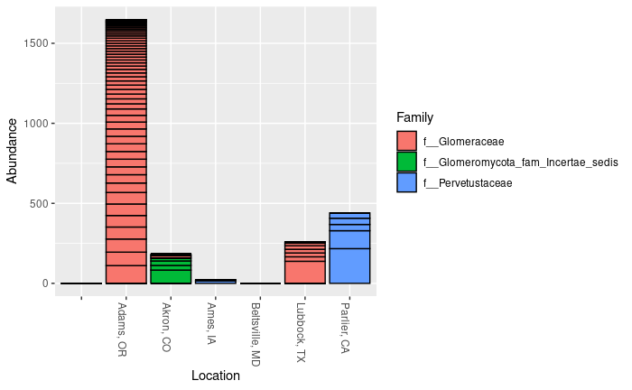

```r
ps.AMF = subset_taxa(ps.thresh, Phylum == "p__Glomeromycota")
plot_bar(ps.AMF, x="Location", fill="Family")
```

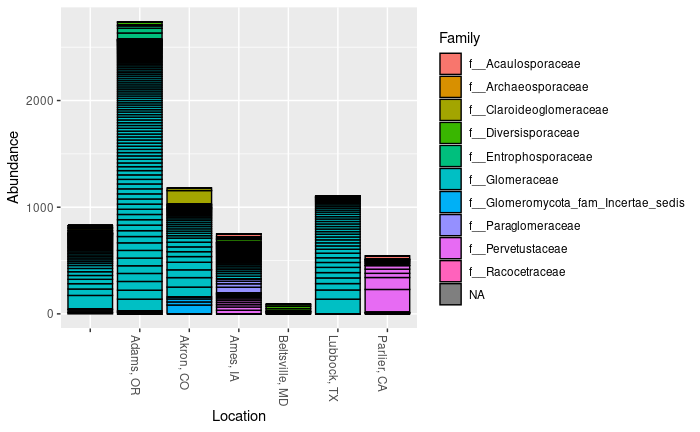

```r
ps.AMF = subset_taxa(ps, Phylum == "p__Glomeromycota")
plot_bar(ps.AMF, x="Location", fill="Family")
```

Looks like many more sequences, now try with just Kelley

```r
ps.KRC = ps %>% subset_samples(Location == "")
ps.KRC
```

```
phyloseq-class experiment-level object
otu_table()   OTU Table:         [ 7214 taxa and 15 samples ]
sample_data() Sample Data:       [ 15 samples by 12 sample variables ]
tax_table()   Taxonomy Table:    [ 7214 taxa by 8 taxonomic ranks ]
```

```r
sample_names(ps.KRC)
```

```
 [1] "KY21_ITS2_1_x_1_R"     "KY21_ITS2_1_x_2_R"     "KY21_ITS2_1_x_3_R"
 [4] "KY21_ITS2_1_x_4_R"     "KY21_ITS2_2_x_1_R"     "KY21_ITS2_2_x_2_R"
 [7] "KY21_ITS2_2_x_3_R"     "KY21_ITS2_2_x_4_R"     "KY21_ITS2_3_x_1_R"
[10] "KY21_ITS2_3_x_2_R"     "KY21_ITS2_3_x_3_R"     "KY21_ITS2_3_x_4_R"
[13] "MLSH_ITS2_PCRBlank1"   "MLSH_ITS2_EXBlank_1_2" "MLSH_ITS2_PCRBlank2"
```

```r
sample_sums(ps.KRC)
```

```
    KY21_ITS2_1_x_1_R     KY21_ITS2_1_x_2_R     KY21_ITS2_1_x_3_R     KY21_ITS2_1_x_4_R
                 8343                 11533                 21500                  8845
    KY21_ITS2_2_x_1_R     KY21_ITS2_2_x_2_R     KY21_ITS2_2_x_3_R     KY21_ITS2_2_x_4_R
                18253                 12033                 12630                 23432
    KY21_ITS2_3_x_1_R     KY21_ITS2_3_x_2_R     KY21_ITS2_3_x_3_R     KY21_ITS2_3_x_4_R
                36690                  8790                 61019                 12382
  MLSH_ITS2_PCRBlank1 MLSH_ITS2_EXBlank_1_2   MLSH_ITS2_PCRBlank2
                    1                    59                     1
```

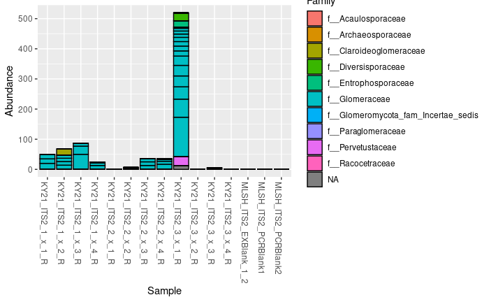

```r
ps.AMF = subset_taxa(ps.KRC, Phylum == "p__Glomeromycota")
plot_bar(ps.AMF, x="Sample", fill="Family")
```

```r
taxa_sums(ps.KRC) %>% sort(.,decreasing = TRUE) %>% .[1:25] %>% names()
```

```
 [1] "ASV3"   "ASV31"  "ASV48"  "ASV21"  "ASV90"  "ASV57"  "ASV12"  "ASV110" "ASV142" "ASV153" "ASV84"  "ASV65"
[13] "ASV24"  "ASV283" "ASV272" "ASV56"  "ASV237" "ASV382" "ASV531" "ASV403" "ASV36"  "ASV80"  "ASV9"   "ASV608"
[25] "ASV649"
```

```r
tax_table(ps.KRC)[namestocheck,]
```

[output not shown]